# Practical Machine Learning - HAR classifier

Jun Xie

Thursday, January 22, 2015

#### Introduction

This project use data [Ref] from accelerometers on the belt, forearm, arm, and dumbell of 6 participants who were asked to perform barbell lifts correctly and incorrectly in 5 different ways. The goal of the HAR project is to predict the manner in which they did the exercise, the “classe” variable in the training set. Use any of the other variables to predict with. Create a report describing how the model is built, how cross validation is applied, what the expected out of sample error is, and why the choices are made. The final prediction model will then be used to predict 20 different test cases.

#### Load libraries

```r
library(caret)
```

#### Load data sets

I use summary() to check the pmltraining and pmltesting data and determine that a number of the 160 variables consist of mostly NA’s or blanks or #DIV/0!, which should be excluded from the clean data that will be fed into the machine learning model.

```r
pmltraining <- read.csv("data/pml-training.csv")
pmltesting <- read.csv("data/pml-testing.csv")
dim(pmltraining)
```

```
## [1] 19622   160
```

```r
summary(pmltraining$classe) #column#160 is "classe" in the training set and "problem_id" in the testing set
```

```
##    A    B    C    D    E
## 5580 3797 3422 3216 3607
```

#### Exploratory Data Analysis and Feature Selection

By using nearZeroVar() on both pmltraining and pmltesting data, I am able to identify a number columns having a majority of NA’s or blanks or “#DIV/0!”, more so with pmltesting (101) than with pmltraining (60). I decide to use nsv_test to select the 59 variables that are clean, the resulting 59 variable can be further reduced by removing the first 6 columns consists of row index, user_name, timestamp, etc.

```r
nsv_train <- nearZeroVar(pmltraining, saveMetrics=FALSE)
nsv_test <- nearZeroVar(pmltesting, saveMetrics=FALSE)
train <- pmltraining[, -nsv_test]
test <- pmltesting[, -nsv_test]
trainData <- train[, 7:59]
testData <- test[, 7:59]
```

#### Data Slicing and Preprocessing

I then split the trainData set into two subsets, train_data for training the ML model and cv_data for cross validating the model. No preprocessing is performed though it would be interesting to see if operations such as PCA will enhance the model.

```r
inTrain <- createDataPartition(y=trainData$classe, p = 0.70, list=FALSE)
train_data <- trainData[inTrain, ]
cv_data <- trainData[-inTrain, ]
dim(train_data); dim(cv_data)
```

```
## [1] 13737    53
```

```
## [1] 5885   53
```

#### Training Model with random forest (‘rf’ in the caret package)

Calculate the variable importance using the varImp function in the caret package. Select two variables with the highest importance to plot the data for visualization. The data are clustered but also overlapped between classe’s on such simple 2D plot.

```r
train_ctrl <- trainControl(method = "oob", number = 4, verboseIter = TRUE)
modFit <- train(classe ~ ., method = "rf", data = train_data, trControl = train_ctrl)
```

```
## + : mtry= 2
## - : mtry= 2
## + : mtry=27
## - : mtry=27
## + : mtry=52
## - : mtry=52
```

```r
modFit
```

```
## Random Forest
##
## 13737 samples
##    52 predictor
##     5 classes: 'A', 'B', 'C', 'D', 'E'
##
## No pre-processing
## Resampling results across tuning parameters:
##
##   mtry  Accuracy   Kappa
##    2    0.9933028  0.9915274
##   27    0.9924292  0.9904230
##   52    0.9873335  0.9839762
##
## Accuracy was used to select the optimal model using  the largest value.
## The final value used for the model was mtry = 2.
```

```r
varImp(modFit)
```

```
## rf variable importance
##
##   only 20 most important variables shown (out of 52)
##
##                      Overall
## roll_belt             100.00
## yaw_belt               76.31
## magnet_dumbbell_z      70.73
## magnet_dumbbell_y      62.95
## pitch_forearm          59.54
## pitch_belt             59.02
## roll_forearm           49.63
## magnet_dumbbell_x      49.44
## accel_dumbbell_y       44.75
## accel_belt_z           42.97
## roll_dumbbell          41.89
## magnet_belt_z          40.97
## magnet_belt_y          39.30
## accel_dumbbell_z       37.45
## roll_arm               34.39
## accel_forearm_x        32.01
## gyros_belt_z           30.53
## accel_dumbbell_x       27.94
## total_accel_dumbbell   26.01
## yaw_dumbbell           26.01
```

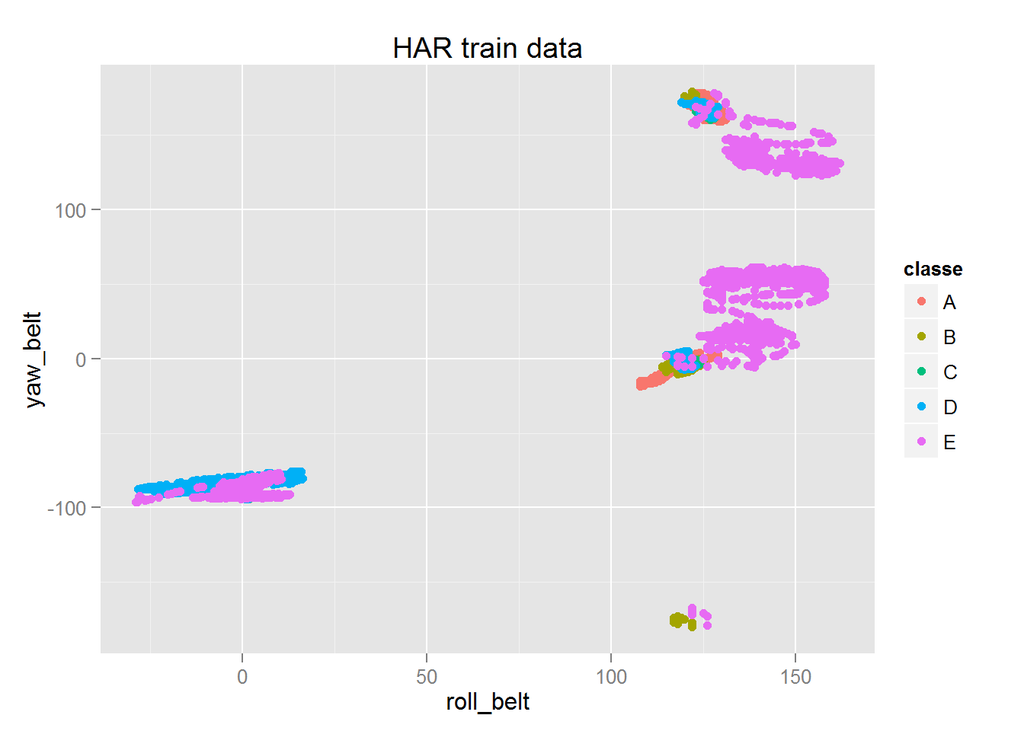

```r
qplot(roll_belt, yaw_belt, colour=classe, data=train_data, main="HAR train data")
```

#### Cross Validating and Estimating Out-of-Sample Errors

The out-of-sample error on the cross-validation set matches the in-sample error. Use two variables with the highest importance to plot the data for visualization. Also plot the data versus “total_accel_belt” and “total_accel_dumbbell” which have relatively higher importance than “total_accel_arm” and “total_accel_forearm”.

```r
pred_activity <- predict(modFit, cv_data[,-53])
confusionMatrix(pred_activity, cv_data$classe)
```

```
## Confusion Matrix and Statistics
##
##           Reference
## Prediction    A    B    C    D    E
##          A 1674    5    0    0    0
##          B    0 1133   10    0    0
##          C    0    1 1015   14    0
##          D    0    0    1  949    5
##          E    0    0    0    1 1077
##
## Overall Statistics
##
##                Accuracy : 0.9937
##                  95% CI : (0.9913, 0.9956)
##     No Information Rate : 0.2845
##     P-Value [Acc > NIR] : < 2.2e-16
##
##                   Kappa : 0.992
##  Mcnemar's Test P-Value : NA
##
## Statistics by Class:
##
##                      Class: A Class: B Class: C Class: D Class: E
## Sensitivity            1.0000   0.9947   0.9893   0.9844   0.9954
## Specificity            0.9988   0.9979   0.9969   0.9988   0.9998
## Pos Pred Value         0.9970   0.9913   0.9854   0.9937   0.9991
## Neg Pred Value         1.0000   0.9987   0.9977   0.9970   0.9990
## Prevalence             0.2845   0.1935   0.1743   0.1638   0.1839
## Detection Rate         0.2845   0.1925   0.1725   0.1613   0.1830
## Detection Prevalence   0.2853   0.1942   0.1750   0.1623   0.1832
## Balanced Accuracy      0.9994   0.9963   0.9931   0.9916   0.9976
```

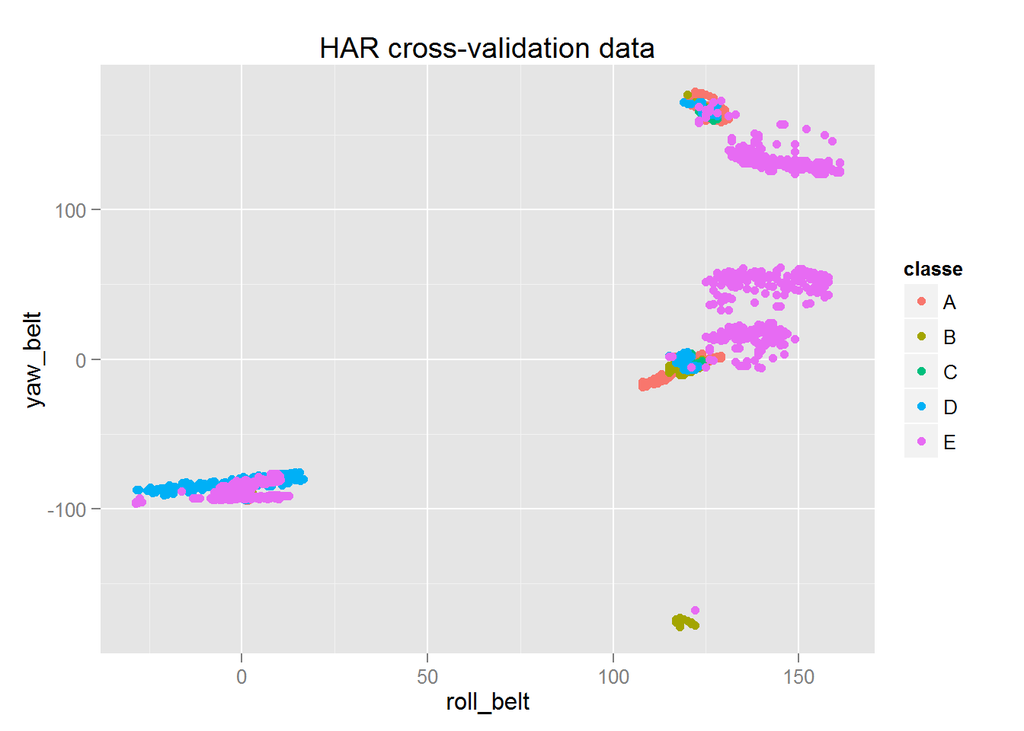

```r
qplot(roll_belt, yaw_belt, colour=classe, data=cv_data, main="HAR cross-validation data")
```

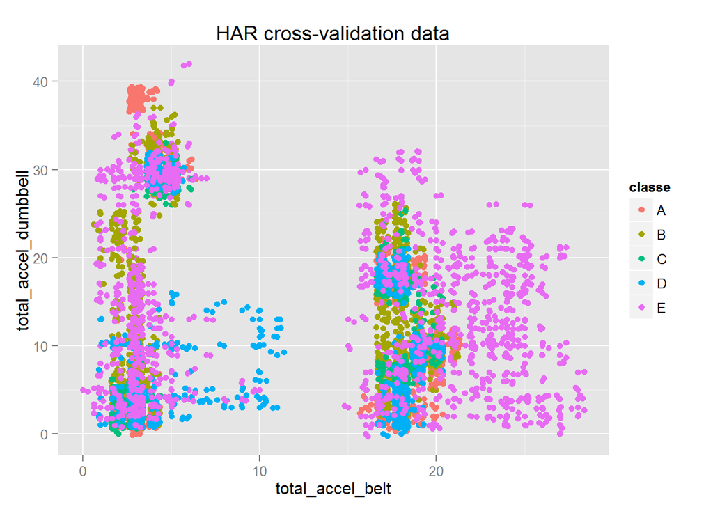

```r
qplot(total_accel_belt, total_accel_dumbbell, colour=classe, data=cv_data, main="HAR cross-validation data", geom = c("auto", "jitter"))
```

#### Making predictions on the pmltesting data set

The prediction results are submitted to the course grader and found to achieve an accuracy of 20/20.

```r
pred_test <- predict(modFit, testData[,-53])
sprintf("The randomForest model predictions of pml-test data are:")
```

```
## [1] "The randomForest model predictions of pml-test data are:"
```

```r
pred_test
```

```
##  [1] B A B A A E D B A A B C B A E E A B B B
## Levels: A B C D E
```

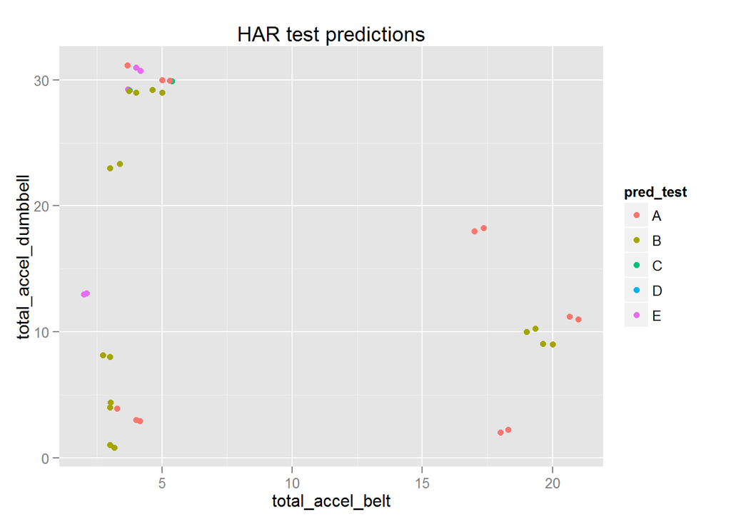

```r
qplot(total_accel_belt, total_accel_dumbbell, colour=pred_test, data=testData, main="HAR test predictions", geom=c("auto", "jitter"))
```

### Summary

#### By selecting a set of clean HAR predictors and then applying Random Forest model, we are able to build a prediction model with greater than 99% accuaracy and use it to predict a set of test cases successfully.

#### Reference

Ugulino, W.; Cardador, D.; Vega, K.; Velloso, E.; Milidiu, R.; Fuks, H. Wearable Computing: Accelerometers’ Data Classification of Body Postures and Movements. Proceedings of 21st Brazilian Symposium on Artificial Intelligence. Advances in Artificial Intelligence - SBIA 2012. In: Lecture Notes in Computer Science. , pp. 52-61. Curitiba, PR: Springer Berlin / Heidelberg, 2012.